# Max Greene Data Science HW9

# Question #1

(Exercise 2, Chapter 3) KNN classifiers have a categorical output at each point, just as classification provides a model for fitting points into categories. Specifically, each point is given some sort of “majority vote,” however that may be defined in a particular model, at each point from it’s k nearest neighbors for which category to join.

KNN regression has a numerical output at each point, just as regression provides a model for fitting a probability of a value at each point. Specifically, each point is given an average of its k nearest neighbors and assigned that numerical value.

# Question #2

## (b)

A female with an IQ of 110 and a GPA of 4.0 is predicted to have a salary of $137.1k = $(50+20(4)+.07(110)+35(1)+.01(4.0*110)-10(4.0*1))*1000$ ##(c) Not necessarily true. If the values for GPA or IQ are relatively large, the coefficient values will be smaller to account for this. The interaction effect is the value of the entire term. For example, the coefficient term for GPA alone is $\beta_1 \times X_1$, which contributes (on average, because mean IQ is 100) 1/100 of the value of $\beta_5 \times X_1 \times X_3$ with equivalent coefficients.

# Question #3

(Conceptual Exercise 5, Chapter 3) $a_i$ here is quivalent to $\frac{1}{x_i}$.

# Question #4

(Applied Exercise 8, Chapter 3)

```r
lmAuto <- lm(data = Auto, formula = mpg ~ horsepower)
summary(lmAuto)
```

```
Call:
lm(formula = mpg ~ horsepower, data = Auto)

Residuals:
     Min       1Q   Median       3Q      Max
-13.5710  -3.2592  -0.3435   2.7630  16.9240

Coefficients:
             Estimate Std. Error t value
(Intercept) 39.935861   0.717499   55.66
horsepower  -0.157845   0.006446  -24.49
                       Pr(>|t|)
(Intercept) <0.0000000000000002 ***
horsepower  <0.0000000000000002 ***
---
Signif. codes:
0 ‘***’ 0.001 ‘**’ 0.01 ‘*’ 0.05 ‘.’ 0.1 ‘ ’ 1

Residual standard error: 4.906 on 390 degrees of freedom
Multiple R-squared:  0.6059,    Adjusted R-squared:  0.6049
F-statistic: 599.7 on 1 and 390 DF,  p-value: < 0.00000000000000022
```

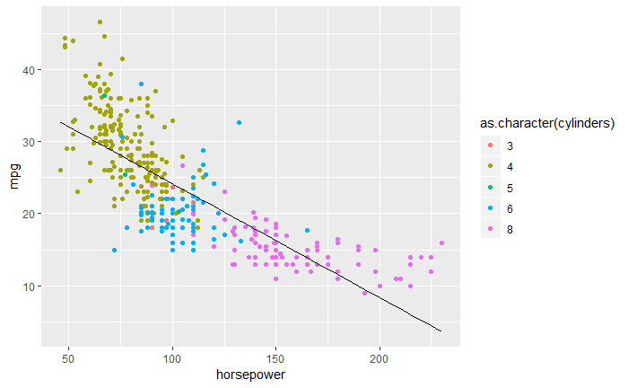

```r
temp <- as.vector(lmAuto$coefficients)
ggplot(Auto) +
  geom_point(mapping = aes(x = horsepower, y = mpg, color = as.character(cylinders))) +
  geom_line(mapping = aes(x = horsepower, y = temp[1]+horsepower*temp[2]))
```

Yes, there is a (negative) relationship between the predictor, horsepower, and the response, mpg. That is, as horsepower increases, mpg tends to decrease, which significant reliability.

# Question #5

(Applied Exercise 9, Chapter 3)

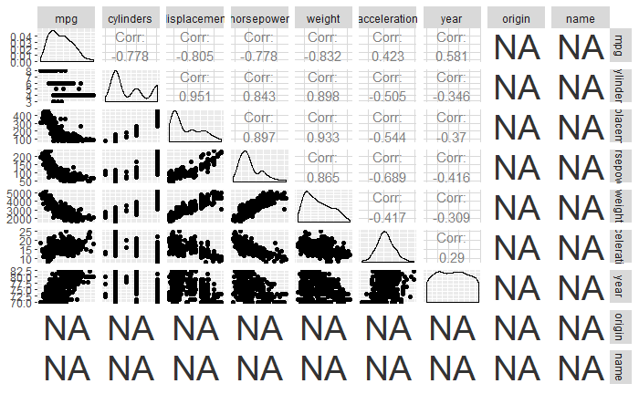

```r
Auto$name <- Auto$origin <- NA
ggpairs(Auto);
```

```r
cor(Auto)
```

```
                    mpg  cylinders displacement
mpg           1.0000000 -0.7776175   -0.8051269
cylinders    -0.7776175  1.0000000    0.9508233
displacement -0.8051269  0.9508233    1.0000000
horsepower   -0.7784268  0.8429834    0.8972570
weight       -0.8322442  0.8975273    0.9329944
acceleration  0.4233285 -0.5046834   -0.5438005
year          0.5805410 -0.3456474   -0.3698552
origin               NA         NA           NA
name                 NA         NA           NA
             horsepower     weight acceleration
mpg          -0.7784268 -0.8322442    0.4233285
cylinders     0.8429834  0.8975273   -0.5046834
displacement  0.8972570  0.9329944   -0.5438005
horsepower    1.0000000  0.8645377   -0.6891955
weight        0.8645377  1.0000000   -0.4168392
acceleration -0.6891955 -0.4168392    1.0000000
year         -0.4163615 -0.3091199    0.2903161
origin               NA         NA           NA
name                 NA         NA           NA
                   year origin name
mpg           0.5805410     NA   NA
cylinders    -0.3456474     NA   NA
displacement -0.3698552     NA   NA
horsepower   -0.4163615     NA   NA
weight       -0.3091199     NA   NA
acceleration  0.2903161     NA   NA
year          1.0000000     NA   NA
origin               NA      1   NA
name                 NA     NA    1
```

```r
mlmAuto <- lm(data = Auto, formula = mpg ~ cylinders + displacement + horsepower + weight + acceleration + year)
summary(mlmAuto)
```

```
Call:
lm(formula = mpg ~ cylinders + displacement + horsepower + weight +
    acceleration + year, data = Auto)

Residuals:
    Min      1Q  Median      3Q     Max
-8.6927 -2.3864 -0.0801  2.0291 14.3607

Coefficients:
                Estimate  Std. Error t value
(Intercept)  -14.5352505   4.7638819  -3.051
cylinders     -0.3298591   0.3321041  -0.993
displacement   0.0076784   0.0073577   1.044
horsepower    -0.0003914   0.0138365  -0.028
weight        -0.0067946   0.0006700 -10.141
acceleration   0.0852732   0.1020356   0.836
year           0.7533672   0.0526181  14.318
                         Pr(>|t|)
(Intercept)               0.00244 **
cylinders                 0.32122
displacement              0.29733
horsepower                0.97745
weight       < 0.0000000000000002 ***
acceleration              0.40383
year         < 0.0000000000000002 ***
---
Signif. codes:
0 ‘***’ 0.001 ‘**’ 0.01 ‘*’ 0.05 ‘.’ 0.1 ‘ ’ 1

Residual standard error: 3.435 on 385 degrees of freedom
Multiple R-squared:  0.8093,    Adjusted R-squared:  0.8063
F-statistic: 272.2 on 6 and 385 DF,  p-value: < 0.00000000000000022
```

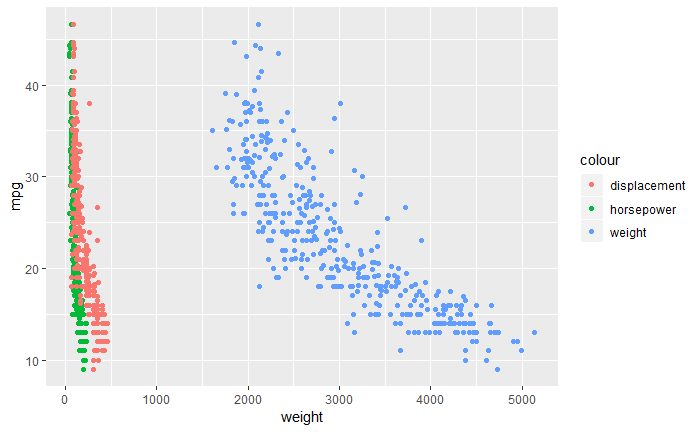

```r
temp <- as.vector(mlmAuto$coefficients)
ggplot(Auto) +
  geom_point(mapping = aes(x = weight,y = mpg, color = "weight")) +
  geom_point(mapping = aes(x = horsepower,y = mpg, color = "horsepower")) +
  geom_point(mapping = aes(x = displacement,y = mpg, color = "displacement"))
```

```r
mlmAuto <- lm(data = Auto, formula = mpg ~ horsepower:displacement + horsepower*displacement)
summary(mlmAuto)
```

```
Call:
lm(formula = mpg ~ horsepower:displacement + horsepower * displacement,
    data = Auto)

Residuals:
     Min       1Q   Median       3Q      Max
-10.9391  -2.3373  -0.5816   2.1698  17.5771

Coefficients:
                           Estimate  Std. Error
(Intercept)             53.05108530  1.52598693
horsepower              -0.23433513  0.01959324
displacement            -0.09804622  0.00668166
horsepower:displacement  0.00058278  0.00005193
                        t value            Pr(>|t|)
(Intercept)               34.77 <0.0000000000000002
horsepower               -11.96 <0.0000000000000002
displacement             -14.67 <0.0000000000000002
horsepower:displacement   11.22 <0.0000000000000002

(Intercept)             ***
horsepower              ***
displacement            ***
horsepower:displacement ***
---
Signif. codes:
0 ‘***’ 0.001 ‘**’ 0.01 ‘*’ 0.05 ‘.’ 0.1 ‘ ’ 1

Residual standard error: 3.944 on 388 degrees of freedom
Multiple R-squared:  0.7466,    Adjusted R-squared:  0.7446
F-statistic:   381 on 3 and 388 DF,  p-value: < 0.00000000000000022
```

```r
mlmAuto <- lm(data = Auto, formula = mpg ~ log10(horsepower))
summary(mlmAuto)
```

```
Call:
lm(formula = mpg ~ log10(horsepower), data = Auto)

Residuals:
     Min       1Q   Median       3Q      Max
-14.2299  -2.7818  -0.2322   2.6661  15.4695

Coefficients:
                  Estimate Std. Error t value
(Intercept)        108.700      3.050   35.64
log10(horsepower)  -42.787      1.526  -28.03
                             Pr(>|t|)
(Intercept)       <0.0000000000000002 ***
log10(horsepower) <0.0000000000000002 ***
---
Signif. codes:
0 ‘***’ 0.001 ‘**’ 0.01 ‘*’ 0.05 ‘.’ 0.1 ‘ ’ 1

Residual standard error: 4.501 on 390 degrees of freedom
Multiple R-squared:  0.6683,    Adjusted R-squared:  0.6675
F-statistic: 785.9 on 1 and 390 DF,  p-value: < 0.00000000000000022
```

Any variation of horsepower I tried (sqrt(horsepower), horsepower^2, log10(horsepower), etc.) produced a significant p-value.

# Question #6

Data that can be well-approximated by a quadratic function:

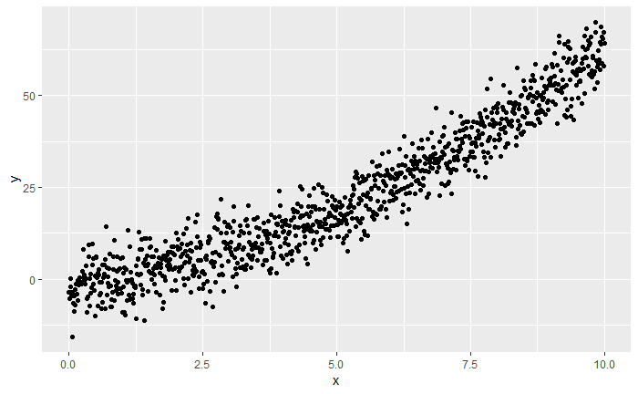

```r
x <- seq(0,10,.01)
y <- x^(1.8)
datadf <- data.frame(x=x,y = (y + rnorm(1001,sd = 5,mean = 0)))
ggplot(datadf) + geom_point(mapping = aes(x = x,y = y))
```

```r
quadlm <- lm(data= datadf, formula = y ~ x + I(x^2))
summary(quadlm)
```

```
Call:
lm(formula = y ~ x + I(x^2), data = datadf)

Residuals:
     Min       1Q   Median       3Q      Max
-14.3100  -3.4887   0.0412   3.2839  14.9603

Coefficients:
            Estimate Std. Error t value
(Intercept) -1.46239    0.47526  -3.077
x            1.56541    0.21953   7.131
I(x^2)       0.48274    0.02125  22.713
                        Pr(>|t|)
(Intercept)              0.00215 **
x               0.00000000000191 ***
I(x^2)      < 0.0000000000000002 ***
---
Signif. codes:
0 ‘***’ 0.001 ‘**’ 0.01 ‘*’ 0.05 ‘.’ 0.1 ‘ ’ 1

Residual standard error: 5.022 on 998 degrees of freedom
Multiple R-squared:  0.9337,    Adjusted R-squared:  0.9336
F-statistic:  7030 on 2 and 998 DF,  p-value: < 0.00000000000000022
```

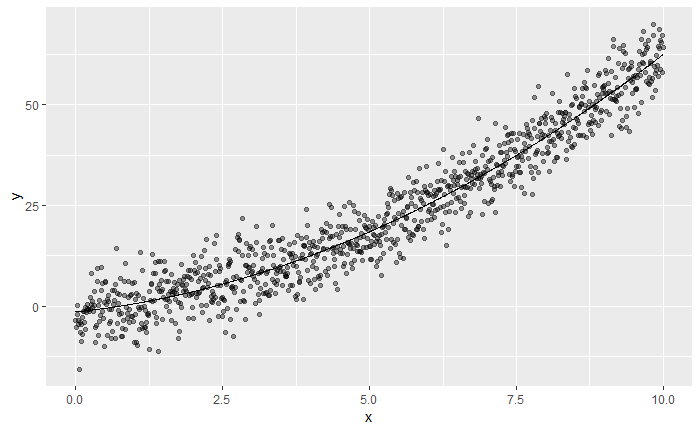

```r
temp <- as.vector(quadlm$coefficients)
ggplot(datadf) +
  geom_point(mapping = aes(x = x, y = y), alpha = .4) +
  geom_line(mapping = aes(x = x , y = temp[1] + temp[2]*x + temp[3]*x^(2)))
```

Data that should not be well-approximated by a quadratic function:

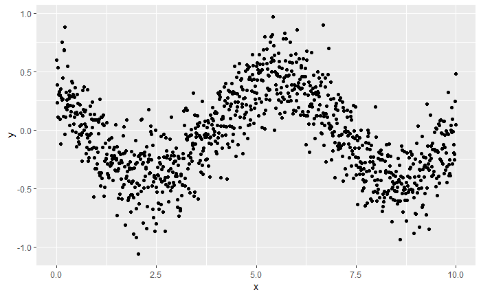

```r
x <- seq(0,10,.01)
y <- sin(x+1) - cos(1-x)
datadf <- data.frame(x=x,y = (y + rnorm(1001,sd = .2,mean = 0)))
ggplot(datadf) + geom_point(mapping = aes(x = x,y = y))
```

```r
quadlm <- lm(data= datadf, formula = y ~ x + I(x^2))
summary(quadlm)
```

```
Call:
lm(formula = y ~ x + I(x^2), data = datadf)

Residuals:
     Min       1Q   Median       3Q      Max
-1.02579 -0.25326 -0.01404  0.25732  1.09499

Coefficients:
             Estimate Std. Error t value
(Intercept) -0.242503   0.032163  -7.540
x            0.132729   0.014856   8.934
I(x^2)      -0.014441   0.001438 -10.040
                        Pr(>|t|)
(Intercept)    0.000000000000106 ***
x           < 0.0000000000000002 ***
I(x^2)      < 0.0000000000000002 ***
---
Signif. codes:
0 ‘***’ 0.001 ‘**’ 0.01 ‘*’ 0.05 ‘.’ 0.1 ‘ ’ 1

Residual standard error: 0.3399 on 998 degrees of freedom
Multiple R-squared:  0.09983,   Adjusted R-squared:  0.09802
F-statistic: 55.34 on 2 and 998 DF,  p-value: < 0.00000000000000022
```

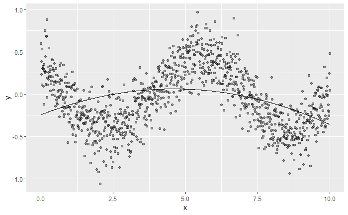

```r
temp <- as.vector(quadlm$coefficients)
ggplot(datadf) +
  geom_point(mapping = aes(x = x, y = y), alpha = .4) +
  geom_line(mapping = aes(x = x , y = temp[1] + temp[2]*x + temp[3]*x^(2)))
```

# Question #7

Using my dataset:

```r
ETHdata <- crypto_history(coin = "ETH");
```

```
Retrieves coin market history from CoinMarketCap.
```

[output not shown]

```
   user  system elapsed
   0.03    0.00    8.51
```

```r
  ETHdata$slug <- NULL
  ETHdata$symbol <- NULL
  ETHdata$name <- NULL
  ETHdata$ranknow <- NULL
nums <- c(10,50)
column <- ETHdata$open
for(i in 1:length(nums))
  {
    varname = paste("ma",i,sep="")
    ETHdata <- dplyr::mutate(ETHdata,!!varname := rollmean(column,nums[i],na.pad=TRUE))
}
ETHdata <- mutate(ETHdata, Last = c(NA,head(column,-1)))
ETHdata <- mutate(ETHdata, Next = c(column[-1],column[1]))
head(ETHdata)
```

|  | date | open | high | low | close | volume | market | close_ratio | spread | ma1 | ma2 | Last | Next |
| --- | --- | --- | --- | --- | --- | --- | --- | --- | --- | --- | --- | --- | --- |
| 1 | 2015-08-07 | 2.830000 | 3.540000 | 2.520000 | 2.770000 | 164329 | 0 | 0.2451 | 1.02 | NA | NA | NA | 2.790000 |
| 2 | 2015-08-08 | 2.790000 | 2.800000 | 0.714725 | 0.753325 | 674188 | 167911008 | 0.0185 | 2.09 | NA | NA | 2.830000 | 0.706136 |
| 3 | 2015-08-09 | 0.706136 | 0.879810 | 0.629191 | 0.701897 | 532170 | 42637600 | 0.2901 | 0.25 | NA | NA | 2.790000 | 0.713989 |
| 4 | 2015-08-10 | 0.713989 | 0.729854 | 0.636546 | 0.708448 | 405283 | 43130000 | 0.7706 | 0.09 | NA | NA | 0.706136 | 0.708087 |
| 5 | 2015-08-11 | 0.708087 | 1.130000 | 0.663235 | 1.070000 | 1463100 | 42796500 | 0.8715 | 0.47 | 1.531821 | NA | 0.713989 | 1.060000 |
| 6 | 2015-08-12 | 1.060000 | 1.290000 | 0.883608 | 1.220000 | 2150620 | 64018400 | 0.8278 | 0.41 | 1.406821 | NA | 0.708087 | 1.220000 |

Fitting a linear model to my data:

```r
lmETH <- lm(data = ETHdata, formula = Next ~ Last)
summary(lmETH)
```

```
Call:
lm(formula = Next ~ Last, data = ETHdata)

Residuals:
     Min       1Q   Median       3Q      Max
-295.762   -2.372   -1.661    1.020  245.810

Coefficients:
            Estimate Std. Error t value            Pr(>|t|)
(Intercept) 1.707394   1.209321   1.412               0.158
Last        0.992811   0.003422 290.150 <0.0000000000000002 ***
---
Signif. codes:  0 ‘***’ 0.001 ‘**’ 0.01 ‘*’ 0.05 ‘.’ 0.1 ‘ ’ 1

Residual standard error: 33.1 on 1183 degrees of freedom
  (1 observation deleted due to missingness)
Multiple R-squared:  0.9861,    Adjusted R-squared:  0.9861
F-statistic: 8.419e+04 on 1 and 1183 DF,  p-value: < 0.00000000000000022
```

```r
lmETH <- lm(data = ETHdata, formula = Next ~ volume:Last)
summary(lmETH)
```

```
Call:
lm(formula = Next ~ volume:Last, data = ETHdata)

Residuals:
     Min       1Q   Median       3Q      Max
-1324.77  -108.48   -99.16   128.98   461.38

Coefficients:
                       Estimate          Std. Error t value
(Intercept) 117.937131563506242   5.089632830903159   23.17
volume:Last   0.000000000197665   0.000000000004034   49.00
                       Pr(>|t|)
(Intercept) <0.0000000000000002 ***
volume:Last <0.0000000000000002 ***
---
Signif. codes:  0 ‘***’ 0.001 ‘**’ 0.01 ‘*’ 0.05 ‘.’ 0.1 ‘ ’ 1

Residual standard error: 161.5 on 1183 degrees of freedom
  (1 observation deleted due to missingness)
Multiple R-squared:   0.67, Adjusted R-squared:  0.6697
F-statistic:  2401 on 1 and 1183 DF,  p-value: < 0.00000000000000022
```

These linear models may not be entirely accurate for my data currently. I would have to alter my data to a daily change, because the variables I am currently using are overall very well correlated.